# Error estimates

#### **Figure 1.**

The difference between model estimated PFAA value and observed (empirically measured values) for each PFAA, species, and in each system. The vertical line at 0 indicates “perfect” agreement between measured and modeled values. The density plots compile model results originated from taking 1000 random draws of realistically measurable values in each system (the randomly selected values include: water, sediment, and species tissue PFAA concentrations, and water temperature; all other parameters were constant). **Only showing results for model runs where PFAA values in diet were modeled via trophic transfer**

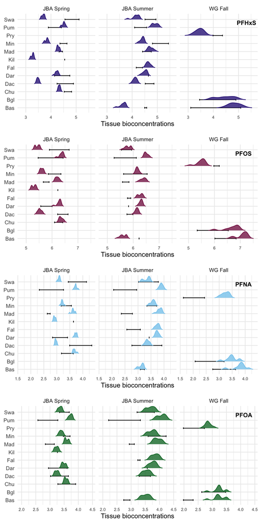

#### **Figure 2.**

The distributions of predicted PFAA tissue bioconcentration values, the error bar mark the range of the empirically measured value. The density plots compile model results originated from taking 1000 random draws of realistically measurable values in each system (the randomly selected values include: water, sediment, and species tissue PFAA concentrations, and water temperature; all other parameters were constant). **Only showing results for model runs where PFAA values in diet were modeled via trophic transfer**

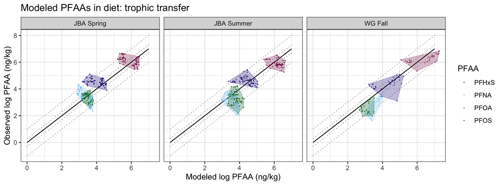

#### **Figure 3.**

The results of all predicted values for each PFAA, and system. Each dot represents a species. The colored polygons connect each PFAA

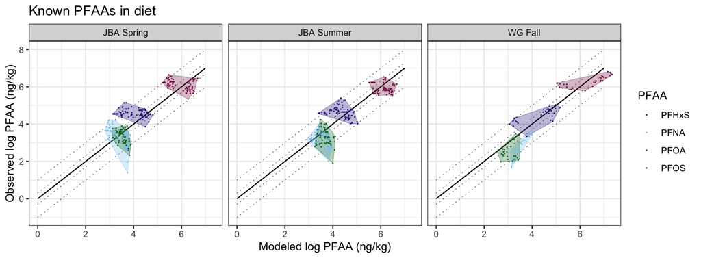

#### **Figure 4.**

The results of all predicted values for each PFAA, and system. Each dot represents a species. The colored polygons connect each PFAA

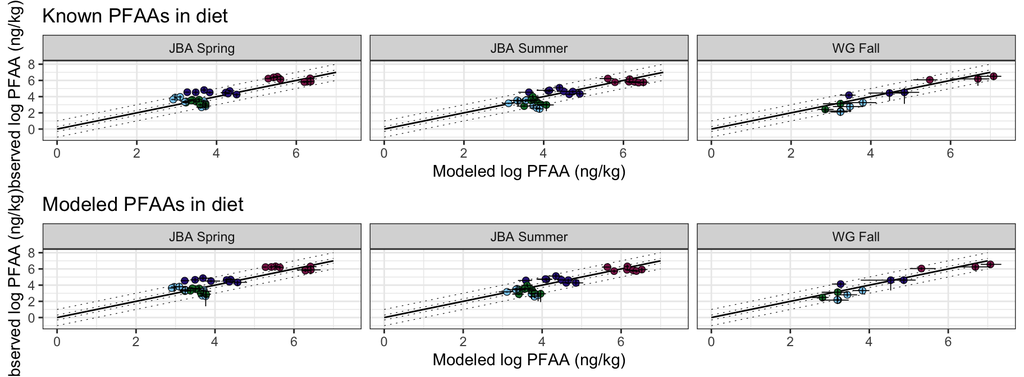

### The variation in diet and water as a source of PFAA

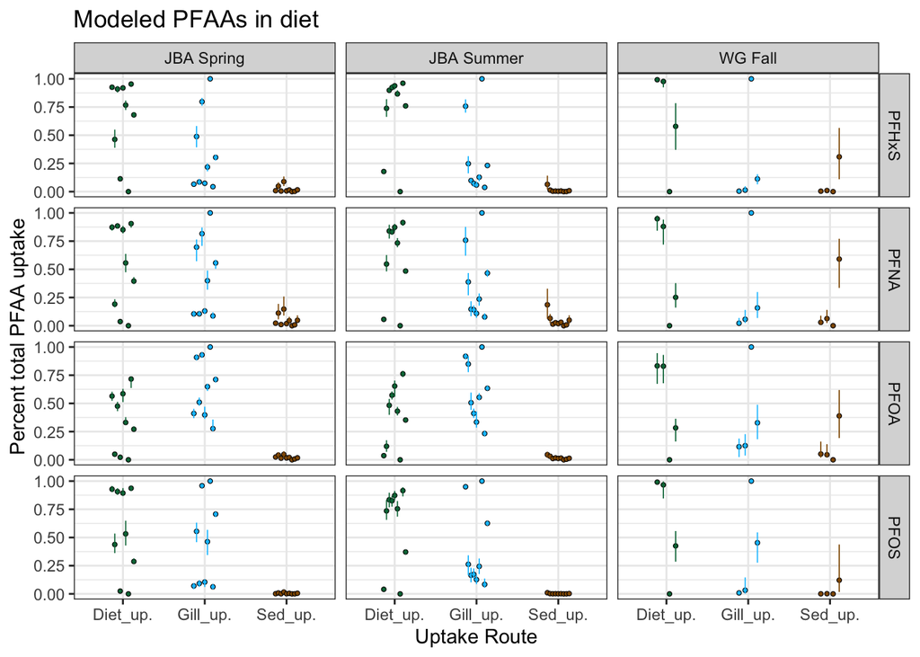